# Regression Diagnostics

Alexandra Chronopoulou

Lecture #15 Example

## Re-visit the Bike Shares Data to discuss how to fit ANCOVA models

```r
library(dplyr)
bikeshares <-  read.csv("BikeShares.csv", header=TRUE)
dim(bikeshares)
head(bikeshares)
```

In this example we are going to focus on three variables: `ctn` (i.e. bike share counts) as the response, and `t1` real temperature and `is_weekend` (weekend/weekday) as predictors.

So, we start by restricting the data set for our purposes (this is just done for illustration purposes):

```r
# We keep columns 2,3,9 and sample only 50 (otherwise the plots are not easy to interpret)
seed = 5434;
bikeshares.ancova = sample_n(bikeshares[ ,c(2,3,9)], 50);
head(bikeshares.ancova);
```

|  | cnt | t1 | is_weekend |
| --- | --- | --- | --- |
| 1 | 31 | -1.0 | 0 |
| 2 | 475 | 11.0 | 1 |
| 3 | 899 | 14.0 | 0 |
| 4 | 4168 | 12.0 | 0 |
| 5 | 344 | 14.0 | 1 |
| 6 | 609 | 11.5 | 1 |

### Fit the Full Model

We start our analysis by fitting the *full* model, that is a model that contains both predictors (`t1`, `is_weekend`), as well as their interaction (`t1:is_weekend`). Essentially, the full model is a model with different intercepts and different slopes for each of the groups.

```r
bikeshares.full = lm(cnt~ t1 + is_weekend + t1:is_weekend, data=bikeshares.ancova)
# same as lm(cnt~ t1 * is_weekend, data=bikeshares.ancova)
summary(bikeshares.full)
```

```
##
## Call:
## lm(formula = cnt ~ t1 + is_weekend + t1:is_weekend, data = bikeshares.ancova)
##
## Residuals:
##     Min      1Q  Median      3Q     Max
## -1543.5  -531.9  -195.0   532.6  2988.2
##
## Coefficients:
##               Estimate Std. Error t value Pr(>|t|)
## (Intercept)     553.64     333.76   1.659   0.1040
## t1               52.18      23.16   2.253   0.0291 *
## is_weekend     -952.70     589.71  -1.616   0.1130
## t1:is_weekend    74.01      47.13   1.570   0.1232
## ---
## Signif. codes:  0 '***' 0.001 '**' 0.01 '*' 0.05 '.' 0.1 ' ' 1
##
## Residual standard error: 918 on 46 degrees of freedom
## Multiple R-squared:  0.2533, Adjusted R-squared:  0.2046
## F-statistic: 5.201 on 3 and 46 DF,  p-value: 0.003542
```

```r
model.matrix(bikeshares.full)
```

```
##    (Intercept)   t1 is_weekend t1:is_weekend
## 1            1 -1.0          0           0.0
## 2            1 11.0          1          11.0
## 3            1 14.0          0           0.0
## 4            1 12.0          0           0.0
## 5            1 14.0          1          14.0
## 6            1 11.5          1          11.5
## 7            1  9.5          0           0.0
## 8            1 13.0          1          13.0
## 9            1 11.0          0           0.0
## 10           1 11.0          0           0.0
## 11           1 15.0          0           0.0
## 12           1 22.0          0           0.0
## 13           1  4.0          1           4.0
## 14           1  7.5          1           7.5
```

[output cut: 38 more lines]

If we plot the fitted model, then we have

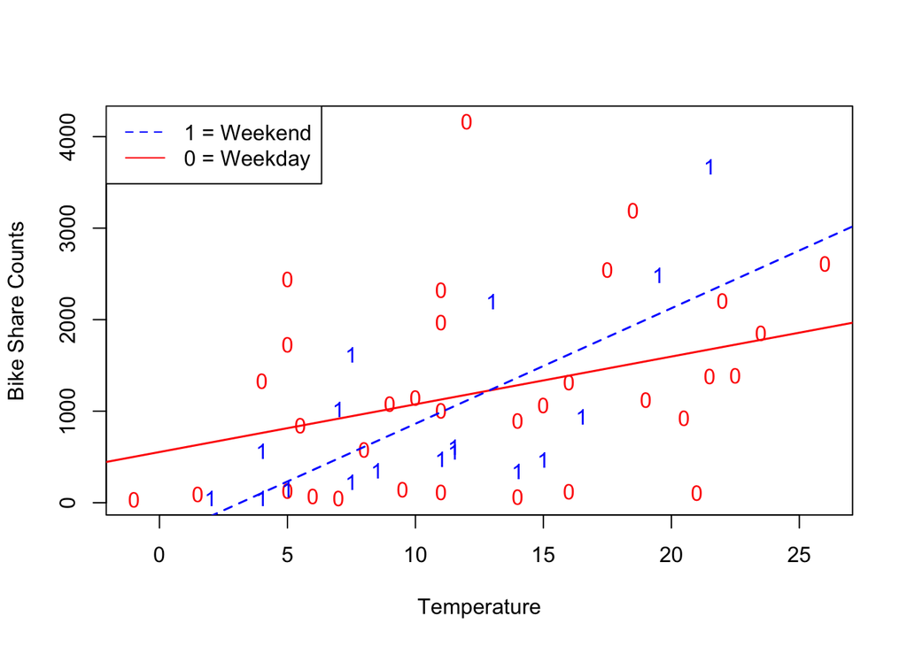

```r
plot(bikeshares.ancova$t1,bikeshares.ancova$cnt,type="n",xlab="Temperature",ylab="Bike Share Counts")
text(bikeshares.ancova$t1[bikeshares.ancova$is_weekend=='0'],bikeshares.ancova$cnt[bikeshares.ancova$is_weekend=='0'], '0', col="red")
text(bikeshares.ancova$t1[bikeshares.ancova$is_weekend=='1'],bikeshares.ancova$cnt[bikeshares.ancova$is_weekend=='1'], '1', col="blue")
abline(bikeshares.full$coef[1], bikeshares.full$coef[2], col="red", lty=1, lwd=1.5)
abline(sum(bikeshares.full$coef[c(1,3)]), sum(bikeshares.full$coef[c(2,4)]), col="blue", lty=2, lwd=1.5)
legend('topleft', c("1 = Weekend","0 = Weekday"), lty=c(2,1), col=c("blue","red"))
```

The full model is **not** the same as if we were fitting a SLR model separately in each group. The coefficients are the same, but **the $t$-statistics are different**, since $\hat{\sigma}$ is not the same. Indeed,

```r
bikeshares.weekday=lm(cnt ~ t1, data=bikeshares.ancova[bikeshares.ancova$is_weekend=='0',]);
bikeshares.weekend=lm(cnt ~ t1, data=bikeshares.ancova[bikeshares.ancova$is_weekend=='1',]);
summary(bikeshares.weekday)
```

```
##
## Call:
## lm(formula = cnt ~ t1, data = bikeshares.ancova[bikeshares.ancova$is_weekend ==
##     "0", ])
##
## Residuals:
##     Min      1Q  Median      3Q     Max
## -1543.5  -687.5  -272.4   565.6  2988.2
##
## Coefficients:
##             Estimate Std. Error t value Pr(>|t|)
## (Intercept)   553.64     360.93   1.534   0.1352
## t1             52.18      25.05   2.083   0.0455 *
## ---
## Signif. codes:  0 '***' 0.001 '**' 0.01 '*' 0.05 '.' 0.1 ' ' 1
##
## Residual standard error: 992.8 on 31 degrees of freedom
## Multiple R-squared:  0.1228, Adjusted R-squared:  0.09453
## F-statistic: 4.341 on 1 and 31 DF,  p-value: 0.04555
```

```r
summary(bikeshares.weekend)
```

```
##
## Call:
## lm(formula = cnt ~ t1, data = bikeshares.ancova[bikeshares.ancova$is_weekend ==
##     "1", ])
##
## Residuals:
##      Min       1Q   Median       3Q      Max
## -1024.79  -495.13   -82.89   461.30  1360.97
##
## Coefficients:
##             Estimate Std. Error t value Pr(>|t|)
## (Intercept)  -399.06     391.88  -1.018  0.32467
## t1            126.19      33.08   3.814  0.00169 **
## ---
## Signif. codes:  0 '***' 0.001 '**' 0.01 '*' 0.05 '.' 0.1 ' ' 1
##
## Residual standard error: 740 on 15 degrees of freedom
## Multiple R-squared:  0.4923, Adjusted R-squared:  0.4585
## F-statistic: 14.55 on 1 and 15 DF,  p-value: 0.001694
```

### Fit the Additive Model

Based on its $p$-value, the interaction term is not statistically significant, so we fit a smaller model without the interaction term; the (additive) model. Since there are no interactions, we have two parallel lines: different intercepts and same slope.

```r
bikeshares.add = lm(cnt~ t1 + is_weekend, data=bikeshares.ancova)
summary(bikeshares.add)
```

```
##
## Call:
## lm(formula = cnt ~ t1 + is_weekend, data = bikeshares.ancova)
##
## Residuals:
##     Min      1Q  Median      3Q     Max
## -1692.7  -510.7  -311.6   432.4  2999.8
##
## Coefficients:
##             Estimate Std. Error t value Pr(>|t|)
## (Intercept)   327.53     305.76   1.071   0.2895
## t1             70.05      20.48   3.420   0.0013 **
## is_weekend   -135.51     281.69  -0.481   0.6327
## ---
## Signif. codes:  0 '***' 0.001 '**' 0.01 '*' 0.05 '.' 0.1 ' ' 1
##
## Residual standard error: 932.2 on 47 degrees of freedom
## Multiple R-squared:  0.2133, Adjusted R-squared:  0.1798
## F-statistic:  6.37 on 2 and 47 DF,  p-value: 0.003565
```

```r
model.matrix(bikeshares.add)
```

```
##    (Intercept)   t1 is_weekend
## 1            1 -1.0          0
## 2            1 11.0          1
## 3            1 14.0          0
## 4            1 12.0          0
## 5            1 14.0          1
## 6            1 11.5          1
## 7            1  9.5          0
## 8            1 13.0          1
## 9            1 11.0          0
## 10           1 11.0          0
## 11           1 15.0          0
## 12           1 22.0          0
## 13           1  4.0          1
## 14           1  7.5          1
```

[output cut: 38 more lines]

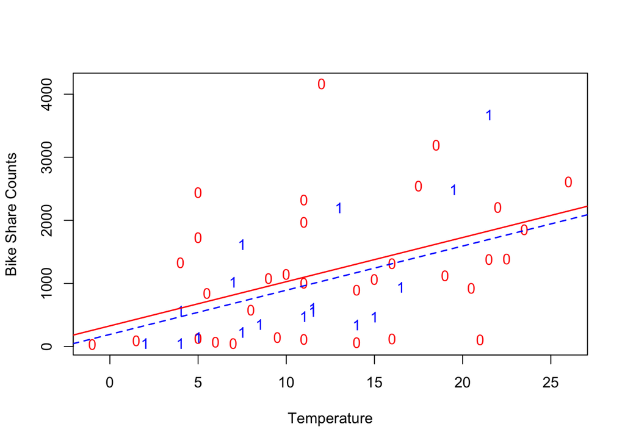

```r
plot(bikeshares.ancova$t1,bikeshares.ancova$cnt,type="n",xlab="Temperature",ylab="Bike Share Counts")
text(bikeshares.ancova$t1[bikeshares.ancova$is_weekend=='0'],bikeshares.ancova$cnt[bikeshares.ancova$is_weekend=='0'], '0', col="red")
text(bikeshares.ancova$t1[bikeshares.ancova$is_weekend=='1'],bikeshares.ancova$cnt[bikeshares.ancova$is_weekend=='1'], '1', col="blue")
abline(bikeshares.add$coef[1:2], col="red", lty=1, lwd=1.5)
abline(sum(bikeshares.add$coef[c(1,3)]), bikeshares.add$coef[2], col="blue", lty=2, lwd=1.5)
```

In this particular data set, we observe that the `is_weekend` variable is not statistically significant. This means that we would remove it and fit a model that only depends on the temperature.

```r
bikeshares.slr = lm(cnt~ t1, data=bikeshares.ancova)
summary(bikeshares.slr)
```

```
##
## Call:
## lm(formula = cnt ~ t1, data = bikeshares.ancova)
##
## Residuals:
##     Min      1Q  Median      3Q     Max
## -1660.4  -526.2  -274.8   457.3  3045.8
##
## Coefficients:
##             Estimate Std. Error t value Pr(>|t|)
## (Intercept)   263.32     272.87   0.965 0.339384
## t1             71.57      20.07   3.565 0.000835 ***
## ---
## Signif. codes:  0 '***' 0.001 '**' 0.01 '*' 0.05 '.' 0.1 ' ' 1
##
## Residual standard error: 924.7 on 48 degrees of freedom
## Multiple R-squared:  0.2094, Adjusted R-squared:  0.1929
## F-statistic: 12.71 on 1 and 48 DF,  p-value: 0.0008346
```